# Handout W03 — Losowość, estymacja i dwa tory wnioskowania

Zarządzanie informacją — mapa odczytu wyniku — 2026/27

Marek Deja

2026/27

# Najpierw wielkość, potem liczba

Estymanda określa wielkość do oszacowania, np. średni czas wskazanego zadania w określonej populacji. Parametr $\mu$ jest odpowiadającą jej wielkością populacyjną. Estymator $\bar{x}$ to reguła obliczenia, a estymata, np. 11,2 minuty, jest wynikiem dla jednej próby.

Średnia wszystkich czasów i średnia czasów udanych prób odpowiadają na dwa pytania. Indeks S02 opisuje deklarowaną użyteczność katalogu według reguły dydaktycznej i zachowuje to znaczenie przy każdym teście.

# Punkt, pole i granica

W modelu trzech niezależnych prób z prawdopodobieństwem sukcesu 0,5 dokładnie dwa sukcesy mają prawdopodobieństwo 3/8, a najwyżej dwa — 7/8. Dystrybuanta $F(k)$ sumuje prawdopodobieństwa do $k$ włącznie. W modelu ciągłym prawdopodobieństwo przedziału to pole $F(b)-F(a)$ pod krzywą gęstości; w modelu wykładniczym o średniej 10 minut $P(5<X\le10)=0{,}239$. Kwantyl wskazuje granicę dla ustalonego udziału: mediana modelu wykładniczego wynosi 6,93 minuty. W R prefiksy d, p, q i r oznaczają gęstość lub prawdopodobieństwo punktu, dystrybuantę, kwantyl i losowanie.

Rozkład normalny $N(\mu,\sigma^2)$ jest symetryczny wokół $\mu$; standaryzacja $Z=(X-\mu)/\sigma$ daje rozkład $N(0,1)$, w którym $P(-1{,}96\le Z\le1{,}96)=0{,}95$. Rozkład t ma grubsze ogony, a różnica maleje ze stopniami swobody.

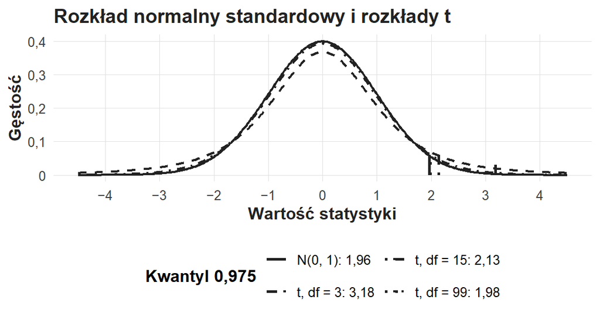

Rozkład normalny standardowy i rozkłady t. Oś pozioma: wartość statystyki; oś pionowa: gęstość. Krzywe są symetryczne wokół zera; kwantyl 0,975 wynosi 3,18 dla t z 3 stopniami swobody, 2,13 dla 15, 1,98 dla 99 i 1,96 dla rozkładu normalnego.

# Mapa symboli

Symbole wykładu W03

| Symbol | Co opisuje | Jednostka |
| --- | --- | --- |
| $n$ | Ważne niezależne jednostki analizy | Osoby lub jednostki projektu |
| $\bar{x}$ | Średnia w próbie | Minuty albo punkty |
| $s$ | Rozrzut obserwacji | Jednostka zmiennej |
| $SE$ | Oszacowany rozrzut estymatora średniej | Jednostka średniej |
| $\mu_0$ | Wartość w hipotezie zerowej | Jednostka średniej |
| $\widehat\Delta$ | Średnia minus odniesienie | Minuty albo punkty |
| $t$ | Różnica wyrażona w SE | Liczba bez jednostki |
| $d$ | Różnica wyrażona w SD osób | Liczba bez jednostki |
| $df$ | Stopnie swobody rozkładu odniesienia | Parametr rozkładu t |
| $B$ | Powtórzenia obliczenia komputerowego | Liczba powtórzeń |

$$SE=\frac{s}{\sqrt n},\qquad
t=\frac{\bar{x}-\mu_0}{SE},\qquad
d=\frac{\bar{x}-\mu_0}{s},\qquad t=d\sqrt{n}.$$

Wzór SE dotyczy niezależnych obserwacji. Wiele kliknięć jednej osoby wnosi informację o jednej osobie. Większe N zwęża przedział; błąd pomiaru i samoselekcja pozostają.

# Przedział ma nazwany parametr

$$CI_{95\%}(\mu):\quad\bar{x}\pm t_{0{,}975;\,n-1}\,SE.$$

Przedział różnicy $\Delta=\mu-\mu_0$ powstaje przez odjęcie $\mu_0$ od obu granic przedziału średniej. Dla średniej punktem sprawdzanym jest $\mu_0$, dla różnicy zero.

Poziom 95% opisuje działanie procedury w powtarzanych próbach: w symulacji 2000 prób po 40 osób przedziały obejmują średnią populacji w 94,35% prób. Czasy osób opisuje zakres środkowych 95% obserwacji, a czas nowej osoby — przedział predykcji; w jednej próbie 40 osób przedział ufności średniej wynosi [8,06; 10,80], środkowe 95% czasów [4,38; 19,86], a przedział predykcji [0,67; 18,19] minuty.

# Dwa przykłady do przeczytania

Dwa przykłady testu t jednej próby

| Wielkość | Indeks: przykład hipotetyczny | Czas: przykład hipotetyczny |
| --- | --- | --- |
| N | 100 | 16 |
| Średnia; SD | 3,24; 0,80 pkt | 11,2; 6 min |
| Odniesienie | 3 pkt | 10 min |
| SE | 0,08 pkt | 1,5 min |
| Różnica | 0,24 pkt | 1,2 min |
| 95% CI różnicy | [0,081; 0,399] pkt | [−2,00; 4,40] min |
| t; df | 3,00; 99 | 0,80; 15 |
| Dwustronne p | 0,0034 | 0,436 |
| d | 0,30 | 0,20 |

Pierwszy wynik jest niezgodny z zerową różnicą w stopniu opisanym przez test; znaczenie praktyczne i trafność indeksu wymagają osobnego kryterium. Drugi wynik jest nieprecyzyjny: przedział obejmuje zero i różnice do 4,4 minuty, więc raport podaje oszacowanie z przedziałem. W obu przykładach wnioskowanie wymaga warunków modelu i uzasadnienia doboru próby.

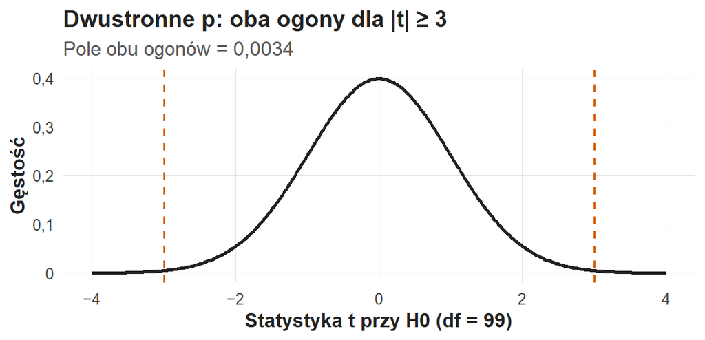

Dwustronne p: oba ogony dla |t| ≥ 3. Krzywa gęstości rozkładu t z 99 stopniami swobody, symetryczna wokół zera; wyróżnione obszary na lewo od −3 i na prawo od 3 mają łączne pole 0,0034.

# Wartość p i poziom α

Wartość p jest prawdopodobieństwem warunkowym wyniku co najmniej tak skrajnego jak obserwowany, obliczonym przy prawdziwej $H_0$ i założeniach modelu; dwustronne p obejmuje oba kierunki. Wielkość efektu opisuje $\widehat\Delta$ albo $d$.

Poziom $\alpha$ jest wcześniej określoną regułą kontroli błędu I rodzaju, $\beta$ — prawdopodobieństwem pozostawienia $H_0$ przy określonej alternatywie, a moc $1-\beta$ zależy od efektu, zmienności, N i $\alpha$. Pozostawienie $H_0$ przy szerokim przedziale oznacza wynik nieprecyzyjny. Wybór najniższego p spośród wielu analiz zmienia działanie procedury: przy 20 niezależnych testach prawdopodobieństwo co najmniej jednego odrzucenia wynosi 0,64.

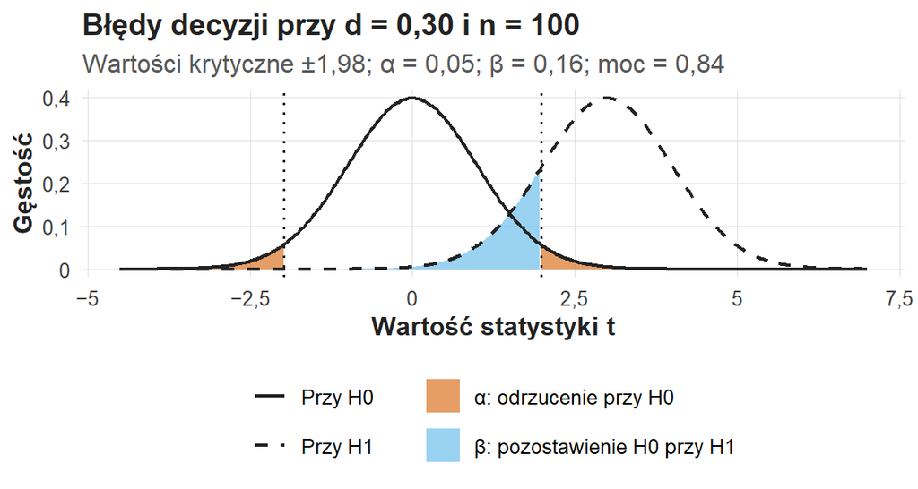

Błędy decyzji przy d = 0,30 i n = 100. Krzywa ciągła: rozkład t przy H0 ze środkiem w zerze; krzywa przerywana: rozkład przy H1 ze środkiem w 3. Pole α = 0,05 leży w ogonach krzywej H0 poza wartościami krytycznymi ±1,98; pole β = 0,16 to część krzywej H1 między nimi; moc wynosi 0,84.

# Dwa zastosowania losowania

Bootstrap losuje obserwacje z powtórzeniami, aby przybliżyć zmienność estymatora; prosty przedział percentylowy wykorzystuje kwantyle 2,5% i 97,5% estymat bootstrapowych. Obciążenie doboru próby pozostaje poza bootstrapem.

Zmiana znaków odchyleń od $\mu_0$ buduje rozkład zerowy przy niezależności i symetrii odchyleń; skośne czasy o średniej równej odniesieniu łamią symetrię. W innych projektach schemat przestawień zachowuje strukturę danych: pary, grupy i obserwacje jednej osoby.

$$p_{\mathrm{MC}}=
\frac{1+\#\{|T_b^*|\geq|T_{\mathrm{obs}}|\}}{B+1}.$$

Dla $B=1999$ i 39 skrajnych powtórzeń $p_{\mathrm{MC}}=40/2000=0{,}02$; najmniejsza osiągalna wartość to $1/2000=0{,}0005$. Zwiększenie $B$ zmniejsza błąd obliczenia Monte Carlo; niepewność wynikająca z małej próby osób zależy od $n$.

# Pytania przed zapisaniem wyniku

Jaka jest estymanda i dla jakiej populacji? Które rekordy tworzą N? Jaka jest wielkość efektu w jednostce problemu? Czy przedział dotyczy średniej czy różnicy? Jakie założenia pozwalają odczytać p? Co przestawiano w teście losowym? Jaką decyzję biblioteki wspiera wynik?

Kompletna odpowiedź łączy dane, liczbę i ograniczenie: „oszacowano tyle, z taką niepewnością, przy takim projekcie”.

Podstawa interpretacji p: [Wasserstein i Lazar, 2016](https://doi.org/10.1080/00031305.2016.1154108). Warunki przestawień: [Winkler i in., 2014](https://pmc.ncbi.nlm.nih.gov/articles/PMC4010955/). Obliczanie losowanych p: [Phipson i Smyth, 2010](https://doi.org/10.2202/1544-6115.1585).